# Самостоятельная работа 1

Данные и матметоды в общественной географии

2023-09-28

В этой работе вам на выбор дается два набора данных. Выполните задания к любому из них.

### Датасет 1: статистика по электромобилям.

Набор содержит данные об электромобилях, которые зарегистрированы в Департаменте лицензирования штата Вашингтон в США.

Ссылка на набор данных и их описание:  
https://catalog.data.gov/dataset/electric-vehicle-population-data.

Скачайте файл с данными в формате csv, импортируйте в RStudio с помощью функции `read_csv()` из пакета dplyr.

#### Задание 1

Сгруппируйте электромобили по году выпуска (`Model Year`) и воспроизведите график ниже:

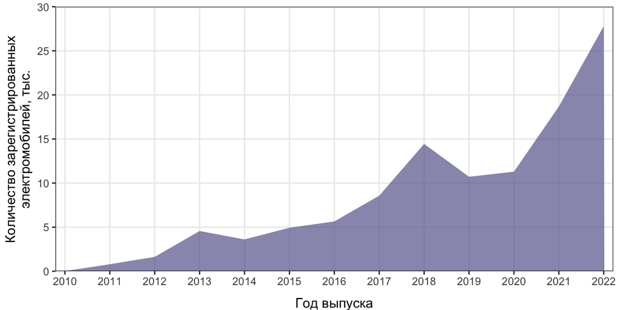

*Подсказки:*  
- для построения графика используйте `geom_area()`, настройте цвет и прозрачность заливки с помощью аргументов `fill` и `alpha`  
- настройте оси x и y с помощью `scale_x_continuous()` и `scale_y_continuous()` соответственно

#### Задание 2

Постройте график, который показывает, как менялась доля крупнейших компаний-производителей (`Make`) зарегистрированных автомобилей за последние пять лет. Используйте любой подходящий `geom_` и разбейте график по годам с помощью `facet_wrap()`.

*Подсказки:*  
- нужно создать отдельную колонку, к которой перезаписать значения из колонки `Make`, оставив названия крупейших производитей, а для остальных указать “Остальные”. Используйте функции `case_when()` или `case_match()`.  
- для отображения пропорций можно использовать разные виды графиков. Посмотрите примеры вот здесь: https://clauswilke.com/dataviz/directory-of-visualizations.html

### Датасет 2: торнадо в США (1950-2022)

Набор содержит данные о торнадо, зарегистрированных Национальным управлением океанических и атмосферных исследований США в 1950-2022 гг.

Ссылка на набор данных и их описание:  
https://www.spc.noaa.gov/wcm/.

Скачайте файл `1950-2022_actual_tornadoes.csv`, импортируйте в RStudio с помощью функции `read_csv()` из пакета dplyr.

#### Задание 1

Сгруппируйте торнадо по году (`yr`) и мощности (`mag`) и воспроизведите график ниже:

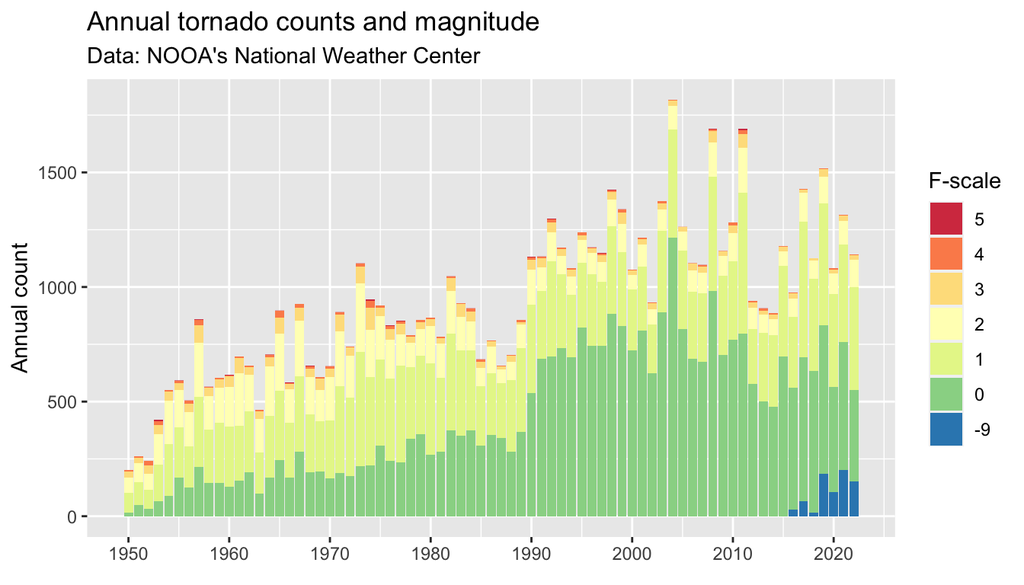

*Подсказки:*  
- для построения графика используйте `geom_col()`  
- настройте цвет с помощью `scale_fill_brewer`, цветовая палитра `Spectral`  
- настройте оси x и y с помощью `scale_x_continuous()` и `scale_y_continuous()` соответственно  
- добавьте заголовок и подзаголовок с помощью `ggtitle()`

#### Задание 2

Постройте график, который показывает, в какие сезоны года (месяцы) чаще всего происходят торнадо. Используйте любой подходящий `geom_`.

*Подсказки:*  
- наблюдения можно сгуппировать по месяцам (`mo`)  
- можно использовать разные виды графиков. Посмотрите примеры вот здесь: https://clauswilke.com/dataviz/directory-of-visualizations.html

### Требования к работам

Работа сдается в виде скрипта с приложенными к нему jpeg файлами.  
Скрипт должен содержать код подгрузки библиотек, импорта данных, предобработки данных, создания графиков и их экспорта. Основные этапы снабжены комментариями.

Работа оценивается по 10-балльной шкале:  
- импорт и предобработка данных (4 балла)  
- создание, оформление и экспорт графиков (4 балла)  
- оформление кода (2 балла)